# Lab 4: Visualization

Isobel Beasley

Due: 12/5/2021

Read in the genes-by-cells read count matrix sc.mat

```r
load("visualization/visualization.RData")
```

**Take a look at a few rows and columns of the matrix**

```r
# print(sc.mat[1:3,1:3])

# not running as causing problems when knitting -
# but runs when just using Rmarkdown interactively,
# so I've cut and pasted the results below

"
3 x 3 sparse Matrix of class \"dgCMatrix\"
           AAACATACCACTCC-1 AAACATACCGCTAA-1 AAACATACTAACGC-1
MIR1302-10                .                .                .
FAM138A                   .                .                .
OR4F5                     .                .                .
"
```

```
## [1] "\n3 x 3 sparse Matrix of class \"dgCMatrix\"\n           AAACATACCACTCC-1 AAACATACCGCTAA-1 AAACATACTAACGC-1\nMIR1302-10                .                .                .\nFAM138A                   .                .                .\nOR4F5                     .                .             …
```

**How many cells?**

```r
ncol(sc.mat)
```

[output not shown]

**How many genes?**

```r
nrow(sc.mat)
```

```
## [1] 32738
```

**Produce a summary of counts for the first cell**

```r
summary(sc.mat[, 1])
```

```
##     Min.  1st Qu.   Median     Mean  3rd Qu.     Max.
##  0.00000  0.00000  0.00000  0.02627  0.00000 57.00000
```

**Produce a summary of counts for the APOL2 gene**

```r
summary(sc.mat["APOL2",])
```

```
##    Min. 1st Qu.  Median    Mean 3rd Qu.    Max.
## 0.00000 0.00000 0.00000 0.00345 0.00000 1.00000
```

```r
# firstly - just get the number of cells that express each gene
n_cell_exp = rowSums(sc.mat > 0)
# then filter by genes that are expressed in at least 10 cells
sc.mat.expr=sc.mat[which(n_cell_exp > 10),]
```

**How many genes are retained?**

```r
nrow(sc.mat.expr)
```

```
## [1] 8900
```

**Normalize to median depth for each cell and take the log** * hint: add a pseudocount of 1 to avoid log(0)

```r
n.umis=median(colSums(sc.mat.expr))
factors = n.umis/colSums(sc.mat.expr)
mat = t(sc.mat.expr) * factors
mat = t(mat)

#mat = sc.mat.expr %*% diag(rep.int(1/n.umis, ncol(sc.mat.expr)))
#colSums(mat)
#colSums(sc.mat.expr / n.umis)
sc.mat.norm=log2(mat+ 1)
#sc.mat.norm=log2(sc.mat.expr %*% (1/n.umis) + 1)
```

**Visualize distribution of normalized expression values for first cell**

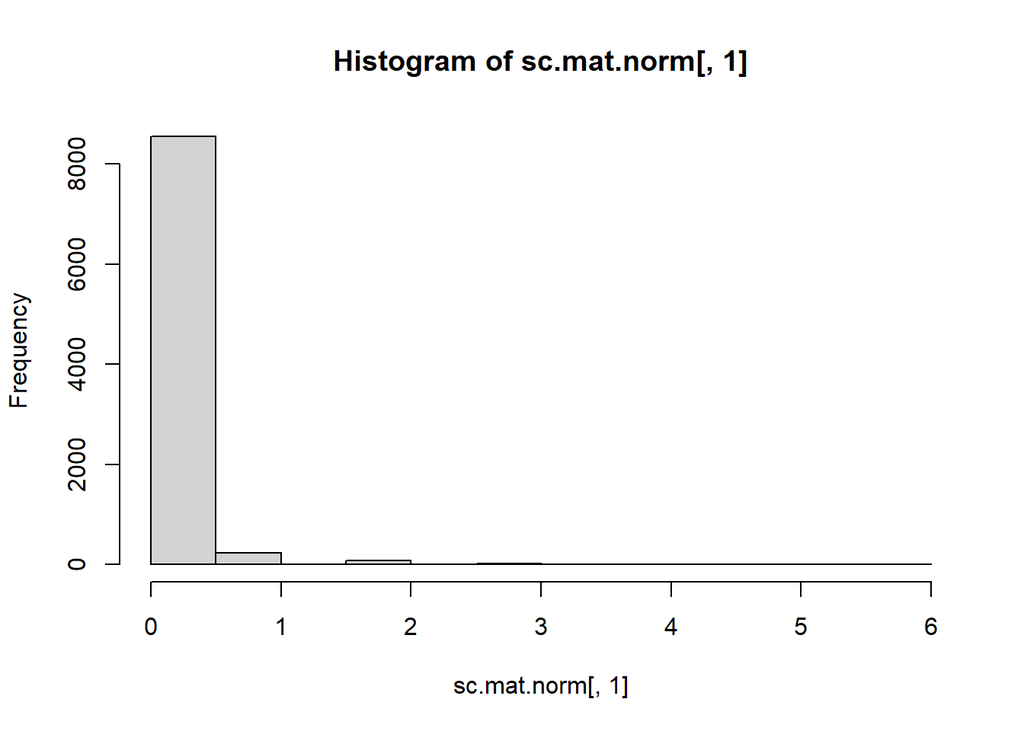

```r
hist(sc.mat.norm[,1])
```

**Visualize distribution of normalized expression values for first gene**

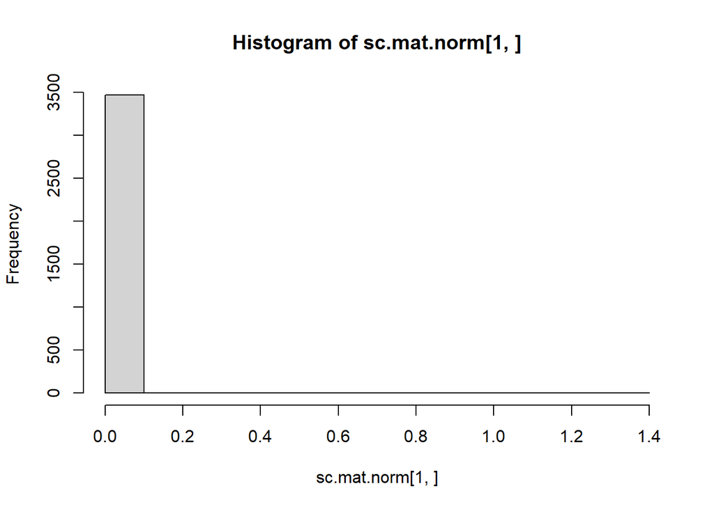

```r
hist(sc.mat.norm[1,])
```

*NOTE: prcomp and Rtsne are slow on a matrix this big, so you can use the saved data frame sc.df that was loaded with the input count matrix two dimensions for PCA and two for tSNE were saved as columns “pc1”, “pc2”, “tsne1”, “tsne2”

**Run PCA on the normalized expression matrix**

```r
pcs=prcomp(sc.mat.norm, rank.=30)
```

**Visualize PCA results**

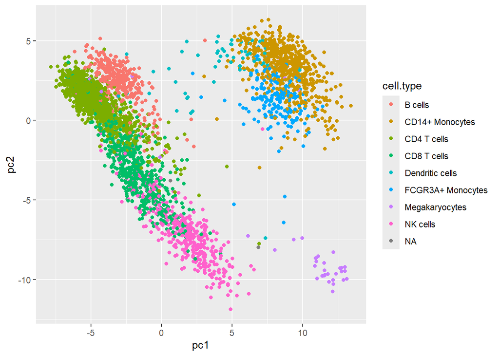

```r
library(ggplot2)
ggplot(sc.df, aes(x=pc1, y=pc2, colour=cell.type)) +
  geom_point()
```

**Run tsne on the normalized expression matrix using PCA as starting values**

```r
library(Rtsne)
tsne=Rtsne(pcs$x)
```

**Visualize TSNE results**

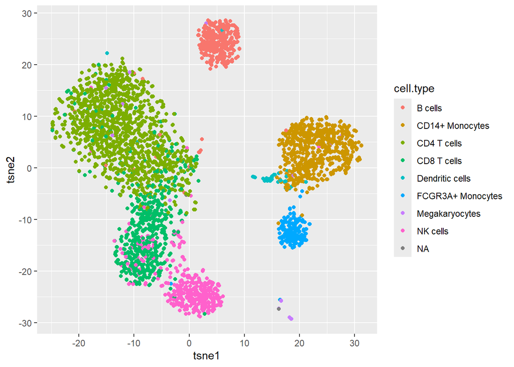

```r
ggplot(sc.df, aes(x=tsne1, y=tsne2, colour=cell.type)) +
  geom_point()
```